```python
import numpy as np
from datascience import *

# These lines do some fancy plotting magic.
import matplotlib
%matplotlib inline
import matplotlib.pyplot as plt

from sklearn.linear_model import LogisticRegression
from sklearn.tree import DecisionTreeClassifier
from sklearn.neighbors import KNeighborsClassifier

from sklearn.metrics import confusion_matrix
from sklearn.metrics import precision_score, recall_score
from sklearn.metrics import accuracy_score
```

# Do You Trust Your Generation to Leave a Better World?

## Introduction

In recent years, climate change, war, global pandemics and natural disasters have shaked our hopes for the future - it seems more uncertain than ever. Despite the advances we have made in technology and medicine (and other broad areas of life), it seems that we have not managed to guarantee a safe and comfortable future for the next generations. Some are hopeful, while others are anxiously speculating disaster. Regardless, I expect that these differing perspective are somewhat influenced by an array of factors which we will use in our predictive models. There is a benefit to knowing which type of people are more likely to pick "Better World" over "Worse World". It could be an indicator of people who are more likely to be optimistic versus people who are less likely to be optimistic about the future. It could also be an indicator of feelings of guilt about the world they will leave behind when they are gone. This kind of information may be valuable to organizations that may want to recruit volunteers for example. Those who believe the world they leave behind is worse, may be more interested in volunteering or being active in change that fact. Of course, a lot of interpretations can be made about the how people think based on their answer to this question.

I will use age, gender, race, education, and political leaning as predictive variables. Their answer to the question of leaving a better world for the next generation will be the outcome to this predicitve problem. The predictive variables I am most concerned about are education and political leaning. Educated people probably have a more informed idea of what the future holds (all things considered). Political leaning is important because it speaks to the prism by which people view the world in many ways!

```python
cah_full = Table().read_table("201808-CAH_PulseOfTheNation.csv").select('Gender', 'Age', 'Race', 'Education', 'Political Leaning', 'Next Generation')
cah = cah_full.where('Gender', are.not_equal_to('DK/REF')).where('Gender', are.not_equal_to('Other')).where('Next Generation', are.not_equal_to('DK/REF'))
cah.show(5)
```

| Gender | Age | Race | Education | Political Leaning | Next Generation |
| --- | --- | --- | --- | --- | --- |
| Female | 81 | White | Some college | Liberal | Worse World |
| Male | 80 | Asian | Some college | Moderate | Better World |
| Female | 65 | Black | High school or less | Moderate | Better World |
| Male | 24 | Asian | College degree | Moderate | Better World |
| Female | 69 | Black | Graduate degree | Moderate | Worse World |

... (721 rows omitted)

```python
degree_earner =  (cah.column('Education') == 'Graduate degree') + (cah.column('Education') == 'College degree')
cah_dummies = cah.with_columns('Male', cah.column('Gender') == 'Male', # True if male, False if female
                               'White', cah.column('Race') == 'White', # True if white, False if not
                               'Black', cah.column('Race') == 'Black', # True if black, False if not
                               'Latino', cah.column('Race') == 'Latino', # True if latino, False if not
                               'Asian', cah.column('Race') == 'Asian', # True if asian, False if not
                               'Degree Earner', degree_earner, # True if earned a graduate degree, False if not
                               'Liberal', cah.column('Political Leaning') == 'Liberal', # True if liberal, false if conservative
                               'Conservative', cah.column('Political Leaning') == 'Conservative', # True if liberal, false if conservative
                               'Better World', cah.column('Next Generation') == 'Better World') # Our outcome. True if 'Better World', False if 'Worse World'

cah_clean = cah_dummies.drop('Gender', 'Race', 'Education', 'Political Leaning', 'Next Generation')
cah_clean.show(5)
```

| Age | Male | White | Black | Latino | Asian | Degree Earner | Liberal | Conservative | Better World |
| --- | --- | --- | --- | --- | --- | --- | --- | --- | --- |
| 81 | False | True | False | False | False | False | True | False | False |
| 80 | True | False | False | False | True | False | False | False | True |
| 65 | False | False | True | False | False | False | False | False | True |
| 24 | True | False | False | False | True | True | False | False | True |
| 69 | False | False | True | False | False | True | False | False | False |

... (721 rows omitted)

## Data Description

```python
cah_clean.group('Better World')
```

| Better World | count |
| --- | --- |
| False | 356 |
| True | 370 |

By creating a logistic regression and observing the size of the coefficients, as well as the sign (+ or -), we can see which variables contribute to the likelihood of people chosing "Better World" vs "Worse World".

```python
logit = LogisticRegression(solver='lbfgs', max_iter=1000) # I kept on getting an error so I increased the max iterations. I hope that does not invalidate the regression model.

predictor = cah_clean.select('Age', 'Male', 'White', 'Black', 'Latino', 'Asian', 'Degree Earner', 'Liberal', 'Conservative').rows
outcome = cah_clean.column('Better World')

logit.fit(X = predictor, y = outcome)
print(logit.coef_)
print(logit.intercept_)
```

```
[[-0.00186453  0.236391   -0.00123858 -0.39389486  0.22043816  1.02871226
   0.15953557 -0.3387767   0.36264488]]
[-0.07647621]
```

```python
cah_clean.pivot('Asian', 'Better World')
```

| Better World | False | True |
| --- | --- | --- |
| False | 352 | 4 |
| True | 355 | 15 |

```python
cah_clean.pivot('Black', 'Better World')
```

| Better World | False | True |
| --- | --- | --- |
| False | 306 | 50 |
| True | 338 | 32 |

```python
cah_clean.pivot('Conservative', 'Better World')
```

| Better World | False | True |
| --- | --- | --- |
| False | 263 | 93 |
| True | 238 | 132 |

```python
cah_clean.pivot('Liberal', 'Better World')
```

| Better World | False | True |
| --- | --- | --- |
| False | 277 | 79 |
| True | 315 | 55 |

It is important to note that we still do not know if these coefficients are statistically significant. Therefore, in the next part of this study, we will identify those coefficients which are statistically significant.

## Confidence Interval

Given that it is hard to tell whether the 'Degree Earner' variable is statistically significant. I will calculate a confidence interval for its coefficent. This is an important variable the variable identifies those who are generally more knowledge about the world than those who are not.

```python
def bootstrap_coef(cah_param):
    bootstrap_cah = cah_param.sample()

    bootstrap_logit = LogisticRegression(solver='lbfgs', max_iter=1000)
    predictor = bootstrap_cah.select('Age', 'Male', 'White', 'Black', 'Latino',
                                             'Asian', 'Degree Earner', 'Liberal', 'Conservative').rows

    outcome = bootstrap_cah.column('Better World')
    bootstrap_logit.fit(X = predictor, y = outcome)

    return bootstrap_logit.coef_

bootstrap_coef(cah_clean)
```

```
array([[-0.00234856,  0.41235899,  0.32731367, -0.22367293,  0.88037199,
         0.57250329,  0.11604505, -0.3234185 ,  0.52984289]])
```

```python
degree_coefs = make_array()
age_coefs = make_array()


for i in np.arange(500):
    coefs = bootstrap_coef(cah_clean)
    degree_coefs = np.append(degree_coefs, coefs.item(6))
```

```python
def confidence_interval(coefficients, confidence_level):
    left = percentile((100-confidence_level)/2, coefficients)
    right = percentile(100 - (100 - confidence_level)/2, coefficients)
    return make_array(left, right)

# 95% confidence interval for mother's age coefficient
confidence_interval(degree_coefs, 95)
```

```
array([-0.17537094,  0.45528853])
```

Because this confidence interval includes 0, the coefficient is not statistically significant in this regression. In other words, we cannot say that being a degree earner has an effect on whether someone believes that world will be better or worse for the next generation.

## Prediction

First, I will check whether logistic regression models are a good predictive model for this problem. If however, it does not show great prediction power, I will try different models and compare them. Between recall and precision, I believe, for this problem, recall scores are more important.

As previously mentioned, there are many reasons why people may want to know if others pick 'Better World' or 'Worse World'. Nonetheless, I do not believe that there is a major cost, in those circumstances, to having too many false positives. Consider a recruiter for volunteers. Besides time and energy, not much else is lost if those they approach reject them. They can quickly pivot to other potential volunteers. It would be sad if they missed out on those who would have probably said yes to their call to be a volunteer.

```python
logit.classes_
```

```
array([False,  True], dtype=bool)
```

```python
logit.predict_proba(predictor)
```

```
array([[ 0.63819028,  0.36180972],
       [ 0.26125324,  0.73874676],
       [ 0.6437242 ,  0.3562758 ],
       ...,
       [ 0.45699834,  0.54300166],
       [ 0.6309466 ,  0.3690534 ],
       [ 0.48317774,  0.51682226]])
```

```python
better_world_probability = logit.predict_proba(predictor)[:,1]
```

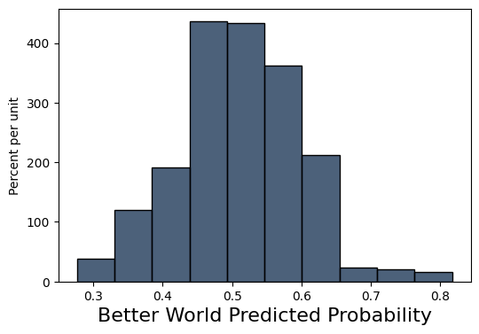

```python
Table().with_column('Better World Predicted Probability', better_world_probability).hist()
```

The graph appears like normally distributed with an approximate median/mean of 0.5. Because the sample is split in half with respect to those who pick 'Better World'. However, the probability upper limit of this distribution is about 0.8. This is not good because it indicates that the model does not have good predictive power.

```python
shuffled_cah = cah_clean.sample(with_replacement = False)

nrows = cah_clean.num_rows
ntrain = int(nrows*.8) # 80% used to train

train = shuffled_cah.take(np.arange(ntrain))
test = shuffled_cah.take(np.arange(ntrain,nrows))
```

```python
# Create a model object
logit_pred = LogisticRegression(solver='lbfgs', max_iter=1000)

# Define predictor and outcome
predictor = train.select('Age', 'Male', 'White', 'Black', 'Latino','Asian', 'Degree Earner', 'Liberal', 'Conservative').rows
outcome = train.column('Better World')

# Fit the model
logit_pred.fit(X = predictor, y = outcome)
```

```
LogisticRegression(max_iter=1000)
```

```python
tree = DecisionTreeClassifier()
knn = KNeighborsClassifier(n_neighbors = 7)

tree.fit(X = predictor, y = outcome)
knn.fit(X = predictor, y = outcome)
```

```
KNeighborsClassifier(n_neighbors=7)
```

```python
test_features = test.select(np.arange(9)).rows
```

```python
expected = test.column('Better World')
```

```python
knn_precision = make_array()
logit_precision = make_array()
tree_precision = make_array()

knn_recall = make_array()
logit_recall = make_array()
tree_recall = make_array()

tree_accuracy = make_array()
knn_accuracy = make_array()
logit_accuracy = make_array()


# Set up models and fit them here
...

for i in make_array(.1,.3,.5,.7,.9):
    knn_predicted = knn.predict_proba(test_features)[:,1] > i
    tree_predicted = tree.predict_proba(test_features)[:,1] > i
    logit_predicted = logit_pred.predict_proba(test_features)[:,1] > i

    knn_precision = np.append(knn_precision, precision_score(expected,knn_predicted))
    logit_precision = np.append(logit_precision, precision_score(expected,logit_predicted))
    tree_precision = np.append(tree_precision, precision_score(expected,tree_predicted))

    knn_recall = np.append(knn_recall, recall_score(expected,knn_predicted))
    logit_recall = np.append(logit_recall, recall_score(expected,logit_predicted))
    tree_recall = np.append(tree_recall, recall_score(expected,tree_predicted))

    knn_accuracy = np.append(knn_accuracy, accuracy_score(test.column('Better World'), knn_predicted))
    logit_accuracy = np.append(logit_accuracy, accuracy_score(test.column('Better World'), logit_predicted))
    tree_accuracy = np.append(tree_accuracy, accuracy_score(test.column('Better World'), tree_predicted))
```

```python
# You can use these to look at results
precision_results = Table().with_columns('Threshold', make_array(.1, .3, .5, .7, .9),
                              'KNN Precision', knn_precision,
                              'Logistic Regression Precision', logit_precision,
                              'Decision Tree Precision', tree_precision)

recall_results = Table().with_columns('Threshold', make_array(.1, .3, .5, .7, .9),
                              'KNN Recall', knn_recall,
                              'Logistic Regression Recall', logit_recall,
                              'Decision Tree Recall', tree_recall)

accuracy_results = Table().with_columns('Threshold', make_array(.1, .3, .5, .7, .9),
                              'KNN Accuracy', knn_accuracy,
                              'Logistic Regression Accuracy', logit_accuracy,
                              'Decision Tree Accuracu', tree_accuracy)
```

```python
precision_results
```

| Threshold | KNN Precision | Logistic Regression Precision | Decision Tree Precision |
| --- | --- | --- | --- |
| 0.1 | 0.475862 | 0.479452 | 0.434783 |
| 0.3 | 0.484615 | 0.479452 | 0.434783 |
| 0.5 | 0.439024 | 0.571429 | 0.441558 |
| 0.7 | 0.44186 | 1 | 0.458333 |
| 0.9 | 0 | 0 | 0.450704 |

```python
recall_results
```

| Threshold | KNN Recall | Logistic Regression Recall | Decision Tree Recall |
| --- | --- | --- | --- |
| 0.1 | 0.985714 | 1 | 0.571429 |
| 0.3 | 0.9 | 1 | 0.571429 |
| 0.5 | 0.514286 | 0.571429 | 0.485714 |
| 0.7 | 0.271429 | 0.0285714 | 0.471429 |
| 0.9 | 0 | 0 | 0.457143 |

```python
accuracy_results
```

| Threshold | KNN Accuracy | Logistic Regression Accuracy | Decision Tree Accuracu |
| --- | --- | --- | --- |
| 0.1 | 0.472603 | 0.479452 | 0.438356 |
| 0.3 | 0.493151 | 0.479452 | 0.438356 |
| 0.5 | 0.452055 | 0.589041 | 0.458904 |
| 0.7 | 0.486301 | 0.534247 | 0.479452 |
| 0.9 | 0.520548 | 0.520548 | 0.472603 |

The model with the highest recall scores are logistic with 0.1 and 0.3 as the threshold. These models have predicted all the true positives (i.e. all the people who picked 'Better World'). These models have an overall accuracy and a precision score less than 50%. This is not a big problem given that there is not that much of a cost with regard to the cases in which this type of information is useful.

## Conclusion

Through the logistical regression models, I was able to guess the direction with which the predictive variables moved. This demonstrates, which factors increase or decrease the likelihood of choosing 'Better World'.

It is important to note that there are many reason why someone may decide 'Better World' over 'Worse World'. I chose to view it as an indicator of someone's willingness to make a change in the world. Others could interpret it differently. For some it could be an indicator of who is more likely to be depressed/anxious/worried about the future. This would be useful for those studying psychology. For example those who are black are more likely to pick 'Worse World'. This may be due to the societal factors of poverty, injustice, and culture. Overall, this project was interesting and its implications not quite clear.

Nonetheless, the models I created were rather inaccurate when predicting what the individuals would pick between 'Better World' and 'Worse World' (approx. 50%). I suspect that most of the predictive variables I chose are not relevant to the outcome variable. Especially for being a degree earner, I was able to determine that the relationship to the outcome variable was not statistically significant.